# Data table and more

GR5293 Statistical Graphic Community Contribution

Chao Yin, Zeyu Yang

## Introduction

`Data table` is a package that provides a high-performance version of base R’s data.frame with syntax and feature enhancements for ease of use, convenience and programming speed<sup>[1]</sup>.

In this article, we will compare `Data table` with other packages to find out the advantages and disadvantages of `Data table`.

## Installation

The latest version of `Data table` is `1.12.0` as of 2019-03-20. You can simply install this package by using *install.packages* command.

```
install.packages("data.table")
```

## Basic syntax

In this part, we are going to introduce the basic syntax of `Data table`.  
We can create one using the `data.table()`.

```r
DT = data.table(
  sample1 = sample(1:10, 4),
  sample2 = sample(11:20, 4),
  sample3 = c('a','b','c','d')
)
DT
```

```
##    sample1 sample2 sample3
## 1:       8      17       a
## 2:       1      14       b
## 3:       9      15       c
## 4:       2      16       d
```

You can also convert existing data.frame and list to a data.table using `setDT()` or `as.data.table()` for other structures. Unlike data.frames, columns of `character` type are never converted to `factors` by default.  
data.table’s general syntax is written as `DT[i, j, by]`, read as *Take DT, subset/reorder rows using `i`, then calculate `j`, grouped by `by`*.

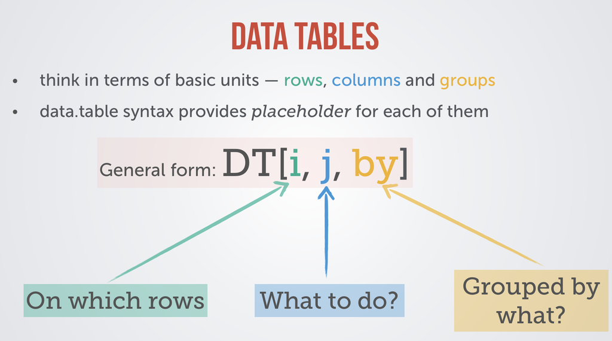

### Subset row(s) in i

```r
DT <- iris
DT <- setDT(DT)
DT[Species == 'setosa' & Sepal.Length > 5.0][1:3]
```

```
##    Sepal.Length Sepal.Width Petal.Length Petal.Width Species
## 1:          5.1         3.5          1.4         0.2  setosa
## 2:          5.4         3.9          1.7         0.4  setosa
## 3:          5.4         3.7          1.5         0.2  setosa
```

Within the frame of a `data.table`, columns can be referred to as if they are variables. We do not need to add the prefix `DT$` each time. A comma after the condition in i is not required. In `data.frames`, however, the comma is necessary.

### Select column(s) in j

Select `Sepal.Length` column, but return it as a *vector*.

```r
DT[, Sepal.Length][1:10]
```

```
##  [1] 5.1 4.9 4.7 4.6 5.0 5.4 4.6 5.0 4.4 4.9
```

Select `Sepal.Length` column, but return as a data.table instead.

```r
DT[, list(Sepal.Length)][1:3]
```

```
##    Sepal.Length
## 1:          5.1
## 2:          4.9
## 3:          4.7
```

Select both `Sepal.Length` and `Sepal.Width` columns and rename them to `Length` and `Width`.

```r
DT[, .(Length = Sepal.Length, Width = Sepal.Width)][1:3]
```

```
##    Length Width
## 1:    5.1   3.5
## 2:    4.9   3.0
## 3:    4.7   3.2
```

### Subset in i and do in j

Calculate the average Sepal.Length and Sepal.Width for all setosa specie.

```r
DT[Species == 'setosa', .(mlen = mean(Sepal.Length), mwid = mean(Sepal.Width))]
```

```
##     mlen  mwid
## 1: 5.006 3.428
```

`.N` is a special built-in variable that holds the number of observations in the current group. In the absence of group by operations, it simply returns the number of rows in the subset.

```r
DT[Species == 'setosa', .N]
```

```
## [1] 50
```

### Grouping using by

How can we get the number of each specie?

```r
DT[, .N, by = Species]
```

```
##       Species  N
## 1:     setosa 50
## 2: versicolor 50
## 3:  virginica 50
```

## Lightning speed

Let’s first preview our .csv file relatively read as data.table, tibble and data.frame. This dataset has 1 million rows with 6 columns which sampled as characters, integers and double.

```
##          sample1      sample2 sample3 sample4 sample5 sample6
##       1:   id027 id0000001402      62    4027       2 53.4276
##       2:   id038 id0000006957      33    9190       3 52.0274
##       3:   id058 id0000007289      21    7011       4  4.4083
##      ---
##  999998:   id081 id0000002287      37    4665       4 10.8610
##  999999:   id070 id0000007561      55    2626       3 98.9201
## 1000000:   id061 id0000003997      16     148       1 21.9067
```

```
## # A tibble: 1,000,000 x 6
##   sample1 sample2      sample3 sample4 sample5 sample6
##   <chr>   <chr>          <dbl>   <dbl>   <dbl>   <dbl>
## 1 id027   id0000001402      62    4027       2   53.4
## 2 id038   id0000006957      33    9190       3   52.0
## 3 id058   id0000007289      21    7011       4    4.41
## 4 id091   id0000000917      84    8531       2   37.2
## 5 id021   id0000000667      15    7745       5    1.70
## # … with 1e+06 more rows
```

```
##   sample1      sample2 sample3 sample4 sample5 sample6
## 1   id027 id0000001402      62    4027       2 53.4276
## 2   id038 id0000006957      33    9190       3 52.0274
## 3   id058 id0000007289      21    7011       4  4.4083
## 4   id091 id0000000917      84    8531       2 37.1531
## 5   id021 id0000000667      15    7745       5  1.7010
##  [ reached 'max' / getOption("max.print") -- omitted 999995 rows ]
```

As a main strength of data.table, the lightening speed of processing data makes it popular among users. This part concerns the running time of conducting functions such as reading, writing, grouping and sorting using different tools and we’ll make it clearly by showing the barplot.

### Reading

```r
dtr <- system.time(fread(setpath))
tbr <- system.time(read_csv(setpath))
dfr <- system.time(read.csv(setpath))
dtr # Data.table reading file
```

```
##    user  system elapsed
##   0.798   0.038   0.108
```

```r
tbr # Tidyverse reading file
```

```
##    user  system elapsed
##   1.237   0.046   0.491
```

```r
dfr # Base R reading file
```

```
##    user  system elapsed
##   1.524   0.047   1.575
```

### Writing

```r
dtw <- system.time(fwrite(DT, setpath))
tbw <- system.time(write_csv(TB, setpath))
dfw <- system.time(write.csv(DF, setpath, row.names = FALSE))
dtw # Data.table writing file
```

```
##    user  system elapsed
##   0.385   0.033   0.060
```

```r
tbw # Tidyverse writing file
```

```
##    user  system elapsed
##   1.990   0.068   1.161
```

```r
dfw # Base R writing file
```

```
##    user  system elapsed
##   1.772   0.054   1.833
```

### Grouping

```r
dtg <- system.time(DT[, .(.N), by = .(sample1)])
tbg <- system.time(
                   TB %>%
                   group_by(sample1) %>%
                   summarise(n1 = n())
                   )
dfg <- system.time(by(DF, DT$sample1, count))
dtg # Data.table grouping
```

```
##    user  system elapsed
##   0.064   0.025   0.014
```

```r
tbg # Tidyverse grouping
```

```
##    user  system elapsed
##   0.363   0.047   0.063
```

```r
dfg # Base R grouping
```

```
##    user  system elapsed
##   0.181   0.017   0.193
```

### Sorting

```r
dts <- system.time(DT[order(sample6)])
tbs <- system.time(TB %>% arrange(sample6))
dfs <- system.time(DF[order(DF$sample6),])
dts # Data.table sorting
```

```
##    user  system elapsed
##   0.468   0.072   0.080
```

```r
tbs # Tidyverse sorting
```

```
##    user  system elapsed
##   1.151   0.030   0.361
```

```r
dfs # Base R sorting
```

```
##    user  system elapsed
##   0.087   0.007   0.094
```

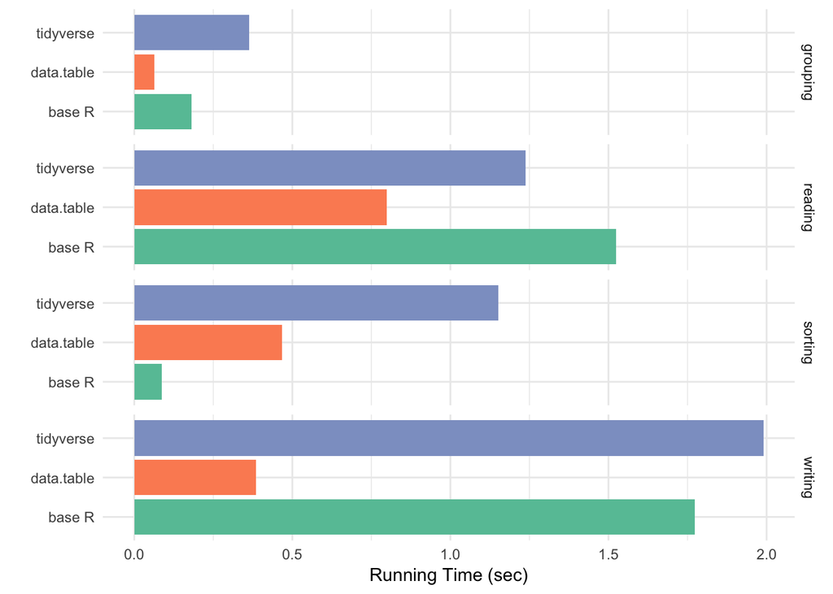

```r
runningtime <- data.frame(
                          time = c(dtr[1], tbr[1], dfr[1], dtw[1], tbw[1], dfw[1],
                                       dtg[1], tbg[1], dfg[1], dts[1], tbs[1], dfs[1]),
                          tool = rep(c('data.table', 'tidyverse', 'base R'), 4),
                          func = rep(c('reading', 'writing', 'grouping', 'sorting'), rep(3,4))
                      )
runningtime %>%
    ggplot() +
    geom_col(aes(x = tool, y = time, fill = tool)) +
    facet_grid(func ~ ., scales = "free", space = "free") +
    coord_flip() +
    scale_fill_brewer(palette = 'Set2') +
    theme_minimal() +
    xlab('') +
    ylab('Running Time (sec)') +
    guides(fill = FALSE)
```

## Data table v.s. Dplyr

`Data table` and `dplyr` are similar in some way. Both of them can manipulate data such as selecting columns, filtering values, sorting data and so on. But their syntaxes are quite different. Here are some examples:

For this part, we are going to use the data from https://data.cityofnewyork.us/City-Government/Citywide-Payroll-Data-Fiscal-Year-/k397-673e. The data is named as *Payroll_data*.

Task 1:

List the 10 agencies `Agency Name` with the highest median base salaries `Base Salary` in descending order by median base salary.

Data table

```r
Payroll_data[,.(median = median(`Base Salary`)),by=.(`Agency Name`)][order(-median)][1:10]
```

```
##                        Agency Name   median
##  1:         DISTRICTING COMMISSION 176099.0
##  2:     FINANCIAL INFO SVCS AGENCY 105875.0
##  3: OFFICE OF COLLECTIVE BARGAININ  99000.0
##  4:       BRONX COMMUNITY BOARD #3  98489.0
##  5:         DEPT OF ED PEDAGOGICAL  82900.0
##  6:      INDEPENDENT BUDGET OFFICE  82012.0
##  7:            OFFICE OF THE MAYOR  79000.0
##  8:       BRONX COMMUNITY BOARD #1  78190.0
##  9:    CONFLICTS OF INTEREST BOARD  78000.0
## 10:       BRONX COMMUNITY BOARD #5  77105.5
```

dplyr

```r
Payroll_data %>%
  group_by(`Agency Name`)%>%
  dplyr::summarize(median = median(`Base Salary`))%>%
  ungroup()%>%
  arrange(-median)%>%
  top_n(10)
```

```
## # A tibble: 10 x 2
##    `Agency Name`                   median
##    <chr>                            <dbl>
##  1 DISTRICTING COMMISSION         176099
##  2 FINANCIAL INFO SVCS AGENCY     105875
##  3 OFFICE OF COLLECTIVE BARGAININ  99000
##  4 BRONX COMMUNITY BOARD #3        98489
##  5 DEPT OF ED PEDAGOGICAL          82900
##  6 INDEPENDENT BUDGET OFFICE       82012
##  7 OFFICE OF THE MAYOR             79000
##  8 BRONX COMMUNITY BOARD #1        78190
##  9 CONFLICTS OF INTEREST BOARD     78000
## 10 BRONX COMMUNITY BOARD #5        77106.
```

Task 2:

For `Pay Basis` == “per Annum” rows, list the mean of `Base Salary`, `Regular Hours` and `Regular Gross Paid` for every combination of `Agency Name` and `Fiscal Year` in descending order by mean base salary. Present the top 10 rows.

Data table

```r
Payroll_data[`Pay Basis` == "per Annum",
        lapply(.SD, mean),
        by = .(`Fiscal Year`, `Agency Name`),
        .SDcols = c("Base Salary", "Regular Hours","Regular Gross Paid")
        ][order(-`Base Salary`)
          ][1:10]
```

```
##     Fiscal Year                    Agency Name Base Salary Regular Hours
##  1:        2014         DISTRICTING COMMISSION    158699.7         0.000
##  2:        2016    BROOKLYN COMMUNITY BOARD #9    138978.0       594.000
##  3:        2017 OFFICE OF COLLECTIVE BARGAININ    115778.8      1825.000
##  4:        2018 OFFICE OF COLLECTIVE BARGAININ    115778.8      1781.750
##  5:        2018     FINANCIAL INFO SVCS AGENCY    109684.0      1664.911
##  6:        2017  PUBLIC ADMINISTRATOR-RICHMOND    109400.8      1520.833
##  7:        2016 OFFICE OF COLLECTIVE BARGAININ    108167.3      1692.611
##  8:        2016  PUBLIC ADMINISTRATOR-RICHMOND    108015.0      1525.000
##  9:        2017     FINANCIAL INFO SVCS AGENCY    107847.7      1704.999
## 10:        2017       BRONX COMMUNITY BOARD #3    107115.0      1825.000
##     Regular Gross Paid
##  1:           7910.243
##  2:          70614.470
##  3:         118979.448
##  4:         114941.314
##  5:         101727.832
##  6:          82937.115
##  7:          99065.806
##  8:          87886.057
##  9:         103801.862
## 10:         109131.555
```

dplyr

```r
Payroll_data%>%
  filter(`Pay Basis` == "per Annum")%>%
  group_by(`Fiscal Year`, `Agency Name`)%>%
  dplyr::summarize(`Base Salary` = mean(`Base Salary`),
                   `Regular Hours` = mean(`Regular Hours`),
                   `Regular Gross Paid` = mean(`Regular Gross Paid`))%>%
  ungroup()%>%
  arrange(-`Base Salary`)%>%
  .[1:10,]
```

```
## # A tibble: 10 x 5
##    `Fiscal Year` `Agency Name` `Base Salary` `Regular Hours`
##            <int> <chr>                 <dbl>           <dbl>
##  1          2014 DISTRICTING …       158700.              0
##  2          2016 BROOKLYN COM…       138978             594
##  3          2017 OFFICE OF CO…       115779.           1825
##  4          2018 OFFICE OF CO…       115779.           1782.
##  5          2018 FINANCIAL IN…       109684.           1665.
##  6          2017 PUBLIC ADMIN…       109401.           1521.
##  7          2016 OFFICE OF CO…       108167.           1693.
##  8          2016 PUBLIC ADMIN…       108015            1525
##  9          2017 FINANCIAL IN…       107848.           1705.
## 10          2017 BRONX COMMUN…       107115            1825
## # … with 1 more variable: `Regular Gross Paid` <dbl>
```

While `data table` and `dplyr` can both provide a flow of actions, `data table` is more concise but may be harder to figure the function of these codes.

`dplyr` is more readable and convenient for multiple actions with the help of `pipeline`. You can understand the function of the action step by step.

## Nice table output

While the output of data frames may be unorganized, data table can also make the output look nicer by applying `DT` library(An R interface to the JavaScript library DataTables). There are also other packages can do the same thing, such as tibble and knitr.

The data we are using is *wine* data from `pgmm` package.

```r
library(pgmm)
data(wine)
wine <- wine[,1:10] # Limiting the number of columns
```

By using *setDT* function, we can turn a data set into data table.

```r
wine_DT <- setDT(wine)
```

```r
wine[1:3,]
```

```
##    Type Alcohol Sugar-free Extract Fixed Acidity Tartaric Acid Malic Acid
## 1:    1   14.23              24.82          73.1          1.21       1.71
## 2:    1   13.20              26.30          72.8          1.84       1.78
## 3:    1   13.16              26.30          68.5          1.94       2.36
##    Uronic Acids   pH  Ash Alcalinity of Ash
## 1:         0.72 3.38 2.43              15.6
## 2:         0.71 3.30 2.14              11.2
## 3:         0.84 3.48 2.67              18.6
```

This table is not organized and not easy to read.

### Data table

```r
library(DT)
datatable(wine[1:50,])
```

|  | Type | Alcohol | Sugar-free Extract | Fixed Acidity | Tartaric Acid | Malic Acid | Uronic Acids | pH | Ash | Alcalinity of Ash |
| --- | --- | --- | --- | --- | --- | --- | --- | --- | --- | --- |
| 1 | 1 | 14.23 | 24.82 | 73.099998 | 1.21 | 1.71 | 0.72 | 3.38 | 2.43 | 15.6 |
| 2 | 1 | 13.2 | 26.299999 | 72.800003 | 1.84 | 1.78 | 0.71 | 3.3 | 2.14 | 11.2 |
| 3 | 1 | 13.16 | 26.299999 | 68.5 | 1.94 | 2.36 | 0.84 | 3.48 | 2.67 | 18.6 |
| 4 | 1 | 14.37 | 25.85 | 74.900002 | 1.59 | 1.95 | 0.72 | 3.43 | 2.5 | 16.799999 |
| 5 | 1 | 13.24 | 26.049999 | 83.5 | 1.3 | 2.59 | 1.1 | 3.42 | 2.87 | 21 |
| 6 | 1 | 14.2 | 28.4 | 79.900002 | 2.14 | 1.76 | 0.96 | 3.39 | 2.45 | 15.2 |
| 7 | 1 | 14.39 | 27.02 | 64.300003 | 1.64 | 1.87 | 0.95 | 3.42 | 2.45 | 14.6 |
| 8 | 1 | 14.06 | 26.4 | 73.5 | 1.33 | 2.15 | 1.14 | 3.54 | 2.61 | 17.6 |
| 9 | 1 | 14.83 | 26.799999 | 69.5 | 1.82 | 1.64 | 0.67 | 3.3 | 2.17 | 14 |
| 10 | 1 | 13.86 | 27 | 68.5 | 1.92 | 1.35 | 0.67 | 3.27 | 2.27 | 16 |

[output cut: 40 more lines]

`Data table`(with the help of `DT` package) provides a tidy and interactive interface to the data. You can browse more data by clicking bottom right corner or present more data per page in upper left corner

### Knitr

```r
library(knitr)
knitr::kable(wine[1:5,])
```

| Type | Alcohol | Sugar-free Extract | Fixed Acidity | Tartaric Acid | Malic Acid | Uronic Acids | pH | Ash | Alcalinity of Ash |
| --- | --- | --- | --- | --- | --- | --- | --- | --- | --- |
| 1 | 14.23 | 24.82 | 73.1 | 1.21 | 1.71 | 0.72 | 3.38 | 2.43 | 15.6 |
| 1 | 13.20 | 26.30 | 72.8 | 1.84 | 1.78 | 0.71 | 3.30 | 2.14 | 11.2 |
| 1 | 13.16 | 26.30 | 68.5 | 1.94 | 2.36 | 0.84 | 3.48 | 2.67 | 18.6 |
| 1 | 14.37 | 25.85 | 74.9 | 1.59 | 1.95 | 0.72 | 3.43 | 2.50 | 16.8 |
| 1 | 13.24 | 26.05 | 83.5 | 1.30 | 2.59 | 1.10 | 3.42 | 2.87 | 21.0 |

`Knitr` also helps organizing the table. But it has fewer functions. You can choose the package based on your needs.

You can learn more about data table at:

- [1] https://github.com/Rdatatable/data.table/wiki
- https://cran.r-project.org/web/packages/data.table/vignettes/datatable-intro.html
- https://rstudio.github.io/DT/